# College Admission Searches

Will the Top-Ranked Schools Change?

Imogen Meers, Sarah Deussing, & Sarah Cernugel

2025-02-09

## Objective

What is the objective of performing time series forecasting and who would it benefit? This analysis will forecast the number of Google Searches for admissions data of the top five nationally ranked U.S. universities. The current U.S. News rankings are as follows:

1. Princeton University
2. Massachusetts Institute of Technology
3. Harvard University
4. Stanford University
5. Yale University

Data was obtained from Google Search statistics for each school; the search terms are “[school name] admission.” Each dataset contains two columns: the date and the number of searches for the term. These are weekly time series with five years of data.

Time-series analysis will be performed to identify trends and seasonality in each dataset. Following, a forecast will predict future weekly search amounts. Doing so will determine if specific schools are projected to rise or fall in popularity.

It is likely that a school projected to see a spike in admissions search numbers in the next year, may have an increase in the number of applications, and thus the difficulty of admission. This would be useful information to determine changes in admission rate and exclusivity of schools in the future.

The audience for this project are high school juniors and seniors, and admission counselors going through the college application process. These students can use the forecasted search numbers and possible ranking changes to determine which schools they should apply to and which may be more or less competitive in the next year. This project can be expanded to include any set of schools in which a person wants to apply.

## Initial Data Analysis

The first step in the time series process is to check if each dataset is a random walk. If so, this means that the the best possible forecast for this dataset is a naive forecast and there is no need to apply any modelling. The following code does so for the top 5 schools’ data.

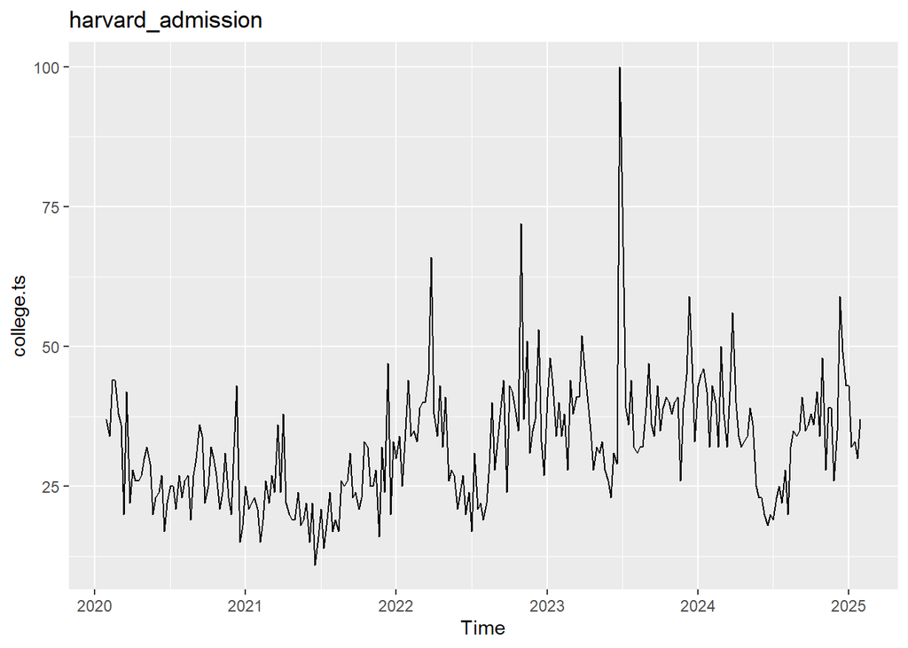

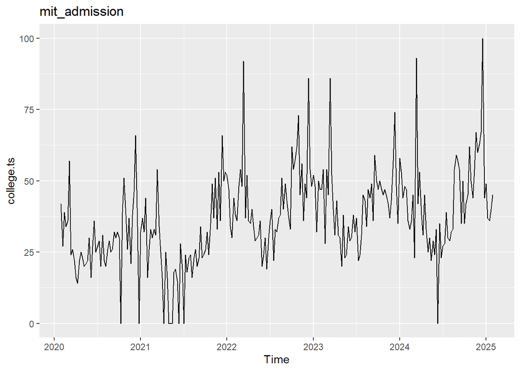

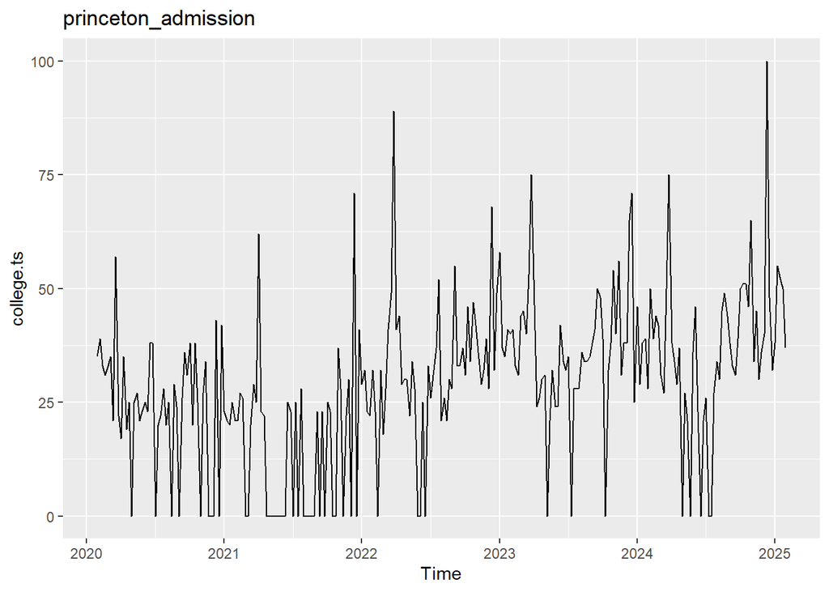

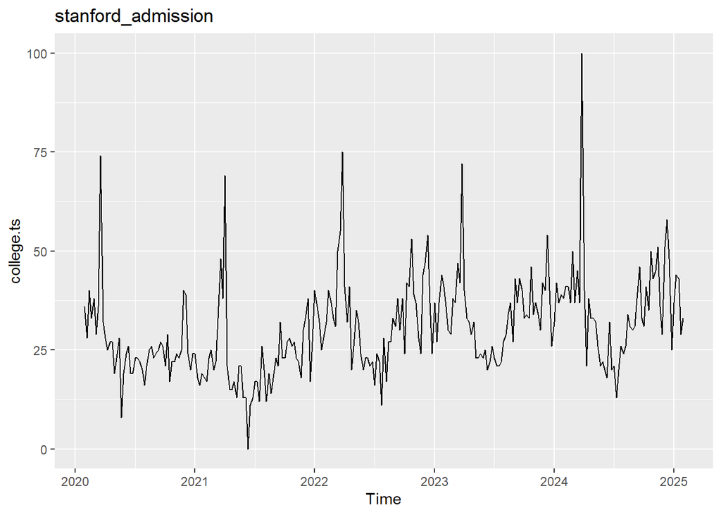

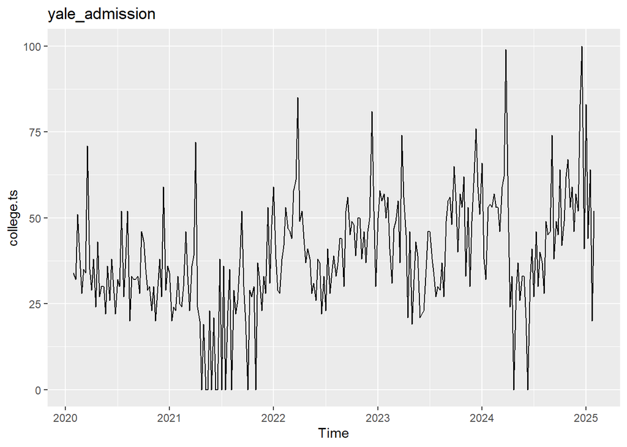

```r
library(forecast)
library(readr)
library(ggplot2)
library(stringr)

file_paths = Sys.glob(file.path("./data", "*"))
data_sets = list()
college_names = list()

for (i in (1:length(file_paths))){

  college.data <- read_delim(file_paths[i], delim = ",", skip = 1)

  college_names[i] = str_extract(string= file_paths[i], pattern = "[a-z]*_admission")

  colnames(college.data) <- c("Week", "Searches")

  college.ts <- ts(college.data$Searches, start = c(2020, 5), end = c(2025, 5), freq = 52) #weekly with a yearly season

  g = autoplot(college.ts) +
  geom_line(color = "black") + labs(title = college_names[i])

  print(g)
  data_sets[[i]] <- college.ts
}
```

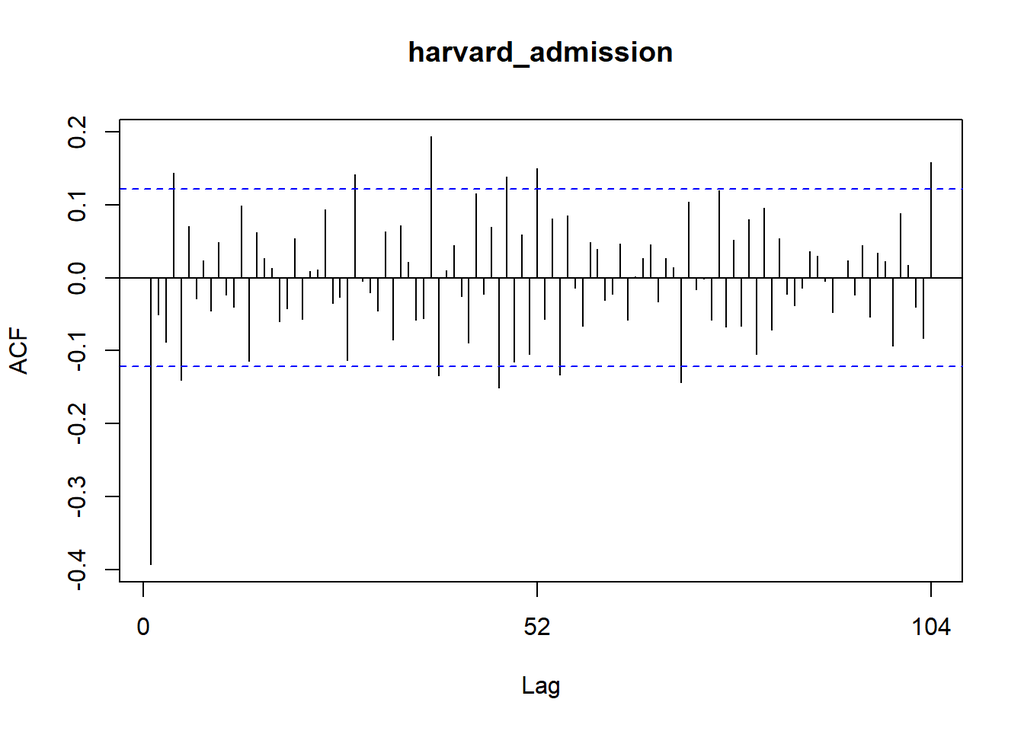

```
##
## Autocorrelations of series 'diff.ts', by lag
##
##      0      1      2      3      4      5      6      7      8      9     10
##  1.000 -0.393 -0.050 -0.088  0.143 -0.140  0.071 -0.029  0.023 -0.045  0.049
##     11     12     13     14     15     16     17     18     19     20     21
## -0.024 -0.040  0.099 -0.114  0.062  0.027  0.013 -0.060 -0.042  0.053 -0.057
##     22     23     24     25     26     27     28     29     30     31     32
##  0.009  0.011  0.094 -0.035 -0.027 -0.113  0.141 -0.005 -0.020 -0.045  0.063
##     33     34     35     36     37     38     39     40     41     42     43
## -0.085  0.071  0.021 -0.058 -0.056  0.193 -0.134  0.010  0.044 -0.026 -0.089
##     44     45     46     47     48     49     50     51     52     53     54
##  0.115 -0.022  0.069 -0.151  0.138 -0.115  0.058 -0.105  0.150 -0.057  0.081
##     55     56     57     58     59     60     61     62     63     64     65
## -0.133  0.085 -0.014 -0.066  0.048  0.040 -0.031 -0.023  0.046 -0.057  0.002
##     66     67     68     69     70     71     72     73     74     75     76
##  0.027  0.046 -0.033  0.026  0.014 -0.144  0.104 -0.016 -0.002 -0.058  0.119
##     77     78     79     80     81     82     83     84     85     86     87
## -0.067  0.052 -0.066  0.079 -0.105  0.095 -0.072  0.054 -0.022 -0.038 -0.014
##     88     89     90     91     92     93     94     95     96     97     98
##  0.036  0.030 -0.004 -0.048 -0.001  0.023 -0.024  0.045 -0.054  0.034  0.022
##     99    100    101    102    103    104
## -0.093  0.088  0.018 -0.040 -0.083  0.158
```

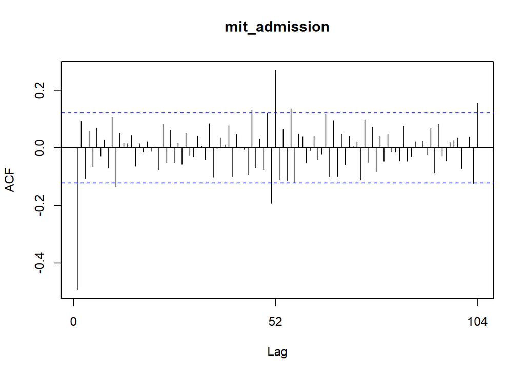

```
##
## Autocorrelations of series 'diff.ts', by lag
##
##      0      1      2      3      4      5      6      7      8      9     10
##  1.000 -0.493  0.093 -0.105  0.057 -0.065  0.070 -0.029  0.028 -0.071  0.106
##     11     12     13     14     15     16     17     18     19     20     21
## -0.135  0.051  0.017  0.015  0.042 -0.064  0.015 -0.014  0.022 -0.013  0.005
##     22     23     24     25     26     27     28     29     30     31     32
## -0.077  0.083 -0.051  0.061 -0.051  0.016 -0.056  0.051 -0.026 -0.032  0.041
##     33     34     35     36     37     38     39     40     41     42     43
##  0.005 -0.040  0.085 -0.103 -0.003  0.034  0.010  0.078 -0.101  0.046 -0.001
##     44     45     46     47     48     49     50     51     52     53     54
## -0.005 -0.093  0.130 -0.069  0.031 -0.075  0.121 -0.193  0.270 -0.109  0.064
##     55     56     57     58     59     60     61     62     63     64     65
## -0.112  0.136 -0.119  0.048  0.038 -0.051 -0.009  0.041 -0.041 -0.023  0.117
##     66     67     68     69     70     71     72     73     74     75     76
## -0.100  0.095 -0.100  0.048 -0.058  0.040  0.006  0.020 -0.111  0.098 -0.051
##     77     78     79     80     81     82     83     84     85     86     87
##  0.072 -0.084  0.041 -0.046  0.048 -0.013 -0.015 -0.045  0.076 -0.046 -0.030
##     88     89     90     91     92     93     94     95     96     97     98
##  0.022  0.001  0.024 -0.024  0.068 -0.088  0.083 -0.029 -0.044  0.019  0.026
##     99    100    101    102    103    104
##  0.034 -0.072  0.000  0.037 -0.123  0.156
```

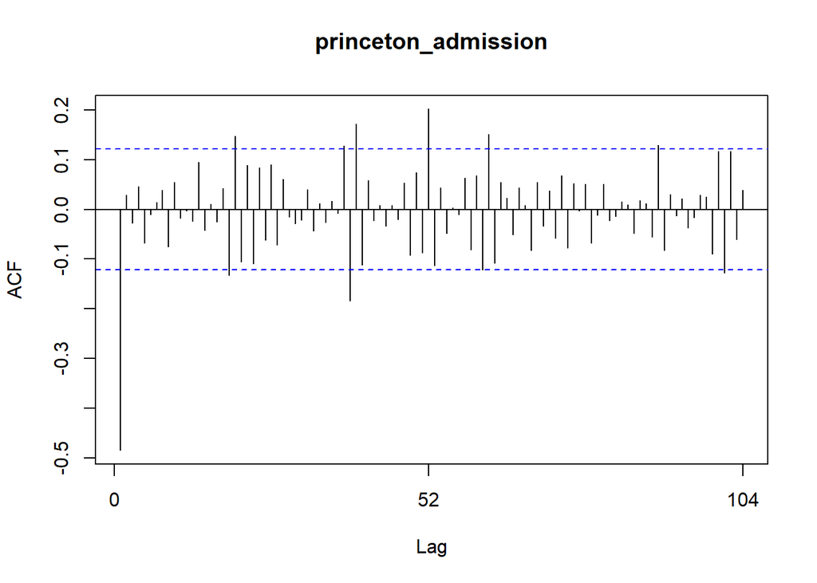

```
##
## Autocorrelations of series 'diff.ts', by lag
##
##      0      1      2      3      4      5      6      7      8      9     10
##  1.000 -0.485  0.028 -0.027  0.046 -0.068 -0.010  0.014  0.038 -0.075  0.055
##     11     12     13     14     15     16     17     18     19     20     21
## -0.018 -0.003 -0.024  0.094 -0.042  0.011 -0.025  0.042 -0.132  0.147 -0.106
##     22     23     24     25     26     27     28     29     30     31     32
##  0.089 -0.109  0.083 -0.062  0.090 -0.072  0.061 -0.015 -0.028 -0.021  0.039
##     33     34     35     36     37     38     39     40     41     42     43
## -0.043  0.012 -0.026  0.016 -0.007  0.128 -0.184  0.171 -0.112  0.058 -0.022
##     44     45     46     47     48     49     50     51     52     53     54
##  0.008 -0.033  0.009 -0.020  0.053 -0.092  0.074 -0.088  0.202 -0.112  0.043
##     55     56     57     58     59     60     61     62     63     64     65
## -0.048  0.003 -0.011  0.062 -0.081  0.068 -0.122  0.151 -0.108  0.054  0.023
##     66     67     68     69     70     71     72     73     74     75     76
## -0.050  0.044  0.008 -0.083  0.054 -0.034  0.038 -0.057  0.068 -0.077  0.052
##     77     78     79     80     81     82     83     84     85     86     87
## -0.002  0.050 -0.068 -0.011  0.050 -0.023 -0.014  0.015  0.009 -0.048  0.018
##     88     89     90     91     92     93     94     95     96     97     98
##  0.011 -0.055  0.129 -0.082  0.030 -0.012  0.021 -0.037 -0.016  0.029  0.025
##     99    100    101    102    103    104
## -0.090  0.116 -0.128  0.116 -0.061  0.039
```

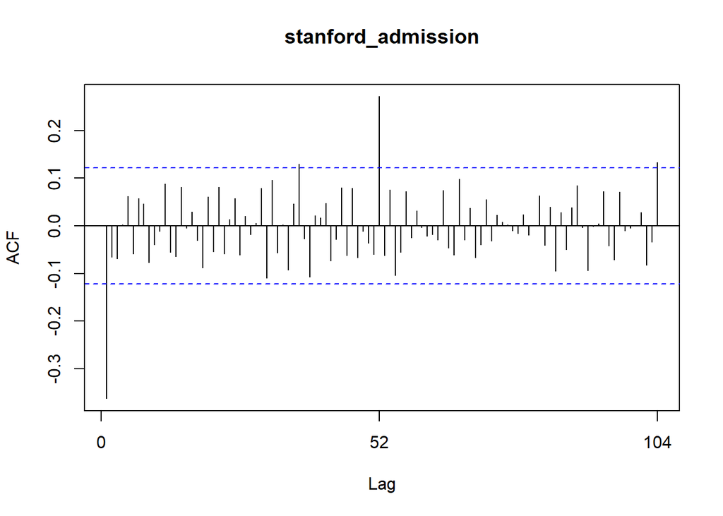

```
##
## Autocorrelations of series 'diff.ts', by lag
##
##      0      1      2      3      4      5      6      7      8      9     10
##  1.000 -0.362 -0.065 -0.069  0.003  0.062 -0.058  0.058  0.046 -0.077 -0.040
##     11     12     13     14     15     16     17     18     19     20     21
## -0.011  0.087 -0.056 -0.064  0.081 -0.004  0.029 -0.030 -0.088  0.061 -0.055
##     22     23     24     25     26     27     28     29     30     31     32
##  0.081 -0.059  0.014  0.058 -0.061  0.021 -0.018  0.005  0.079 -0.109  0.096
##     33     34     35     36     37     38     39     40     41     42     43
## -0.056  0.002 -0.093  0.046  0.129 -0.027 -0.107  0.021  0.016  0.047 -0.073
##     44     45     46     47     48     49     50     51     52     53     54
## -0.029  0.080 -0.062  0.079 -0.067 -0.012 -0.036 -0.060  0.271 -0.062  0.076
##     55     56     57     58     59     60     61     62     63     64     65
## -0.104 -0.055  0.073 -0.025  0.031 -0.003 -0.022 -0.018 -0.030  0.075 -0.047
##     66     67     68     69     70     71     72     73     74     75     76
## -0.061  0.098 -0.030  0.037 -0.066 -0.040  0.056 -0.032  0.023  0.008  0.003
##     77     78     79     80     81     82     83     84     85     86     87
## -0.011 -0.016  0.024 -0.019  0.001  0.063 -0.040  0.039 -0.095  0.028 -0.049
##     88     89     90     91     92     93     94     95     96     97     98
##  0.038  0.084 -0.003 -0.093 -0.001  0.004  0.072 -0.042 -0.071  0.071 -0.010
##     99    100    101    102    103    104
## -0.004  0.000  0.028 -0.083 -0.034  0.133
```

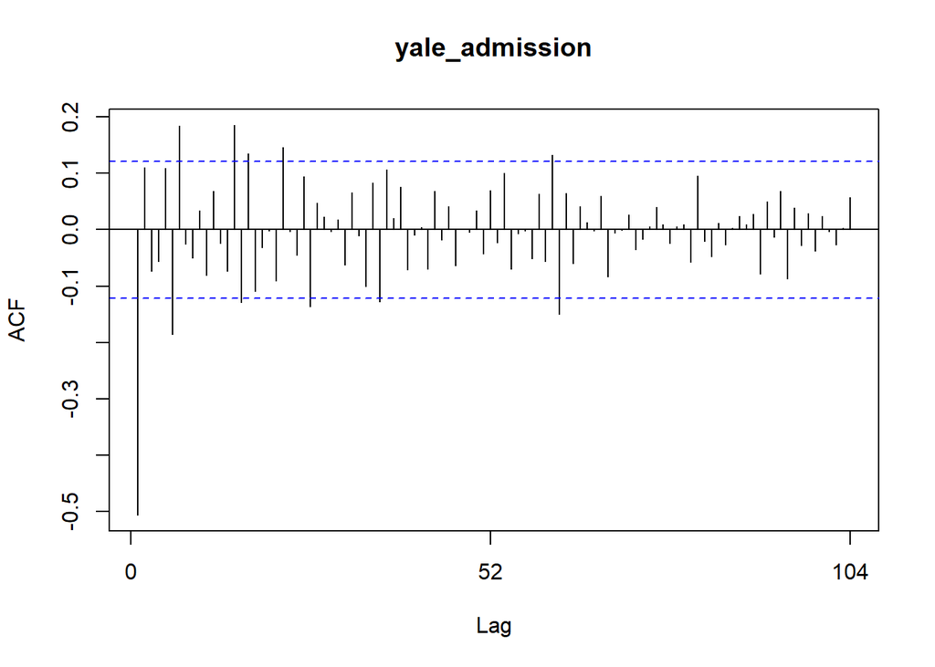

```
##
## Autocorrelations of series 'diff.ts', by lag
##
##      0      1      2      3      4      5      6      7      8      9     10
##  1.000 -0.506  0.111 -0.074 -0.057  0.109 -0.185  0.184 -0.025 -0.050  0.033
##     11     12     13     14     15     16     17     18     19     20     21
## -0.080  0.068 -0.023 -0.073  0.185 -0.129  0.134 -0.109 -0.031 -0.002 -0.091
##     22     23     24     25     26     27     28     29     30     31     32
##  0.146 -0.003 -0.045  0.094 -0.137  0.048  0.023 -0.003  0.018 -0.062  0.066
##     33     34     35     36     37     38     39     40     41     42     43
## -0.011 -0.100  0.083 -0.127  0.106  0.020  0.075 -0.070 -0.009  0.004 -0.070
##     44     45     46     47     48     49     50     51     52     53     54
##  0.068 -0.017  0.042 -0.064  0.001 -0.004  0.034 -0.042  0.070 -0.023  0.100
##     55     56     57     58     59     60     61     62     63     64     65
## -0.070 -0.006 -0.002 -0.052  0.063 -0.056  0.132 -0.149  0.065 -0.060  0.041
##     66     67     68     69     70     71     72     73     74     75     76
##  0.013 -0.001  0.060 -0.083 -0.006 -0.001  0.027 -0.035 -0.016  0.005  0.040
##     77     78     79     80     81     82     83     84     85     86     87
##  0.010 -0.024  0.005  0.010 -0.057  0.095 -0.020 -0.048  0.011 -0.027  0.003
##     88     89     90     91     92     93     94     95     96     97     98
##  0.024  0.009  0.028 -0.078  0.050 -0.013  0.068 -0.087  0.039 -0.028  0.029
##     99    100    101    102    103    104
## -0.038  0.024 -0.003 -0.026  0.003  0.058
```

```r
for (i in (1:length(file_paths))){

  college.ts = data_sets[[i]]

  diff.ts <- diff(college.ts)

  print(Acf(diff.ts, main = college_names[i]))
}
```

All ACF plots show significant correlation after differencing meaning these time series are not random walks.

To further prove this, we will also perform hypothesis testing.

```r
for (i in (1:length(file_paths))){

  college.ts = data_sets[[i]]

  college.ar.1 <- Arima(college.ts, order = c(1, 0, 0))

  print(college_names[i])
  print(summary(college.ar.1))

  ar1_intercept <- summary(college.ar.1)$coef["ar1"]
  ar1_se <- sqrt(diag(college.ar.1$var.coef))['ar1']

  print(paste("Is significant?" , -1.96 > (ar1_intercept-1)/ar1_se))


}
```

```
## [[1]]
## [1] "harvard_admission"
##
## Series: college.ts
## ARIMA(1,0,0) with non-zero mean
##
## Coefficients:
##          ar1     mean
##       0.5410  32.1289
## s.e.  0.0518   1.2341
##
## sigma^2 = 85.16:  log likelihood = -949.53
## AIC=1905.05   AICc=1905.14   BIC=1915.74
##
## Training set error measures:
##                       ME     RMSE      MAE       MPE     MAPE      MASE
## Training set -0.01336627 9.192862 6.409002 -7.591661 21.61592 0.6834089
##                    ACF1
## Training set -0.1136559
## [1] "Is significant? TRUE"
## [[1]]
## [1] "mit_admission"
##
## Series: college.ts
## ARIMA(1,0,0) with non-zero mean
##
## Coefficients:
##          ar1     mean
##       0.5335  36.9580
## s.e.  0.0521   1.7727
##
## sigma^2 = 181.4:  log likelihood = -1048.2
## AIC=2102.4   AICc=2102.5   BIC=2113.1
##
## Training set error measures:
##                       ME     RMSE     MAE  MPE MAPE      MASE       ACF1
## Training set -0.01340186 13.41698 9.79822 -Inf  Inf 0.8324504 -0.1795623
## [1] "Is significant? TRUE"
## [[1]]
## [1] "princeton_admission"
```

[output cut: 37 more lines]

```
## Series: college.ts
## ARIMA(1,0,0) with non-zero mean
##
## Coefficients:
##          ar1     mean
##       0.4725  38.9622
## s.e.  0.0544   1.7403
##
## sigma^2 = 223.1:  log likelihood = -1075.17
## AIC=2156.34   AICc=2156.44   BIC=2167.04
##
## Training set error measures:
##                      ME     RMSE      MAE  MPE MAPE      MASE       ACF1
## Training set 0.01146582 14.87987 11.42511 -Inf  Inf 0.7663186 -0.1552487
## [1] "Is significant? TRUE"
```

We can conclude that all our coefficients are significantly different from 0.

Null Hypothesis: beta = 1 (i.e., random walk)

Alternative Hypothesis: beta not equal to 1 (i.e., not random walk)

To be specific, our t-stat = (coefficient - 1)/s.e = t-stat = +-/1.96 at 95% confidence interval

All t-stat are < -1.96 so are significant, there is significant evidence to reject null hypothesis. These time series are not random walks.